# ANOVA Assumptions and Kruskal-Wallis

**STA4173: Biostatistics**  
Spring 2025

## Introduction: ANOVA Assumptions

- We previously discussed testing three or more means using ANOVA.
- We also discussed that ANOVA is an extension of the two-sample *t*-test.
- Recall that the *t*-test has two assumptions:
  - Equal variance between groups.
  - Normal distribution.
- We will extend our knowledge of checking assumptions today.

## ANOVA Assumptions: Definition

- We can represent ANOVA with the following model:

$$y_{ij} = \mu + \tau_i + \varepsilon_{ij}$$

- where:
  - $y_{ij}$ is the $j^{\text{th}}$ observation in the $i^{\text{th}}$ group,
  - $\mu$ is the overall (grand) mean,
  - $\tau_i$ is the treatment effect for group $i$, and
  - $\varepsilon_{ij}$ is the error term for the $j^{\text{th}}$ observation in the $i^{\text{th}}$ group.

## ANOVA Assumptions: Definition

- We assume that the error term follows a normal distribution with mean 0 and a constant variance, $\sigma^2$. i.e.,
  $$\varepsilon_{ij} \overset{\text{iid}}{\sim} N(0, \sigma^2)$$
- Very important note: **the assumption is on the error term** and NOT on the outcome!
- We will use the residual (the difference between the observed value and the predicted value) to assess assumptions:
  $$e_{ij} = y_{ij} - \hat{y}_{ij}$$

## ANOVA Assumptions: Graphical Assessment

- **Normality**: quantile-quantile plot
  - Should have points close to the 45$^\circ$ line
  - We will focus on the “center” portion of the plot
- **Variance**: scatterplot of the residuals against the predicted values
  - Should be “equal spread” between the groups
  - No “pattern”

## ANOVA Assumptions: Graphical Assessment

- Like with *t*-tests, we will assess these assumptions graphically.
- We will return to the `classpackage` package and use the `anova_check()` function.

```r
library(classpackage)
anova_check(m)
```

## ANOVA Assumptions: Graphical Assessment

- Recall the dental example from last week,

```r
library(tidyverse)
strength <- c(15.4, 12.9, 17.2, 16.6, 19.3,
              17.2, 14.3, 17.6, 21.6, 17.5,
               5.5,  7.7, 12.2, 11.4, 16.4,
              11.0, 12.4, 13.5,  8.9,  8.1)
system <- c(rep("Cojet",5), rep("Silistor",5), rep("Cimara",5), rep("Ceramic",5))
data <- tibble(system, strength)
m <- aov(strength ~ system, data = data)
summary(m)
```

```
            Df Sum Sq Mean Sq F value  Pr(>F)
system       3  200.0   66.66   7.545 0.00229 **
Residuals   16  141.4    8.84
---
Signif. codes:  0 '***' 0.001 '**' 0.01 '*' 0.05 '.' 0.1 ' ' 1
```

## ANOVA Assumptions: Assessing Graphically

- Let’s assess the assumptions,

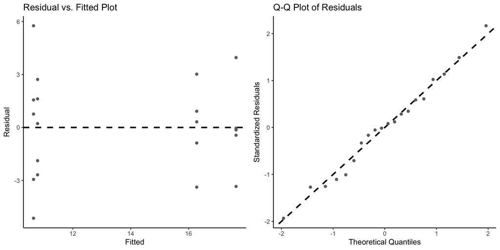

```r
library(classpackage)
anova_check(m)
```

## ANOVA Assumptions: Test for Variance

- We can formally check the variance assumption with the Brown-Forsythe-Levine test.
  - This test transforms the data and then performs ANOVA!
- The test statistic is calculated as follows,
  $$F_0 = \frac{\sum_{i=1}^k n_i (\bar{z}_i - \bar{z})^2/(k-1)}{\sum_{i=1}^k \sum_{j=1}^{n_j}(z_{ij}-\bar{z}_i)^2/(n-k) },$$
  where
  - $k$ is the number of groups,
  - $n_i$ is the sample size of group i,
  - $n = \sum_{i=1}^k n_i$, and
  - $z_{ij} = |y_{ij} - \text{median}(y_i)|$

## ANOVA Assumptions: Test for Variance

- **Hypotheses**
  - $H_0: \ \sigma^2_1 = ... = \sigma^2_k$
  - $H_1:$ at least one $\sigma^2_i$ is different
- **Test Statistic**
  - $F_0$ (take from resulting ANOVA table)
- *p*-Value
  - $p = P[F_{\text{df}_{\text{Trt}}, \text{df}_{\text{E}}} \ge F_0]$
- **Rejection Region**
  - Reject if $p < \alpha$.

## ANOVA Assumptions: Test for Variance

- We will use the [`leveneTest()`](https://www.rdocumentation.org/packages/car/versions/3.1-0/topics/leveneTest) function from the [`car`](https://www.rdocumentation.org/packages/car/versions/3.1-0) package.
  - Note: I do not load the `car` package because it overwrites a necessary function in `tidyverse`.

```r
car::leveneTest(model_results)
```

- In our dental example,

```r
car::leveneTest(m)
```

|  | Df | F value | Pr(>F) |
| --- | --- | --- | --- |
| group | 3 | 0.7339467 | 0.5468532 |
|  | 16 | NA | NA |

## ANOVA Assumptions: Test for Variance

- **Hypotheses**
  - $H_0: \ \sigma^2_1 = \sigma^2_2 = \sigma^2_3 = \sigma^2_4$
  - $H_1:$ at least one $\sigma^2_i$ is different
- **Test Statistic and *p*-Value**
  - $F_0 = 0.734$
  - $p = 0.547$
- **Rejection Region**
  - Reject if $p < \alpha$; $\alpha=0.01$.
- **Conclusion/Interpretation**
  - Fail to reject $H_0$. There is not sufficient evidence to suggest that the variances are different (i.e., the variance assumption is not broken).

## Introduction: Kruskal-Wallis

- We just discussed the ANOVA assumptions.

$$\varepsilon_{ij} \overset{\text{iid}}{\sim} N(0, \sigma^2)$$

- We also discussed how to assess the assumptions:
  - Graphically using the `anova_check()` function.
  - Confirming the variance assumption using the BFL.
- If we break an assumption, we will turn to the nonparametric alternative, the Kruskal-Wallis.

## Kruskal-Wallis Test

- If we break ANOVA assumptions, we should implement the nonparametric version, the Kruskal-Wallis.
- The Kruskal-Wallis test determines if $k$ independent samples come from populations with the same distribution.
- Our new hypotheses are
  - $H_0: M_1 = ... = M_k$
  - $H_1:$ at least one $M_i$ is different

## Kruskal-Wallis Test

- The test statistic is as follows:

$$\chi^2_0 = \frac{12}{n(n+1)} \sum_{i=1}^k \frac{R_i^2}{n_i} - 3(n+1),$$

- where
  - $R_i$ is the sum of the ranks for group $i$,
  - $n_i$ is the sample size for group $i$,
  - $n = \sum_{i=1}^k n_i$ = total sample size, and
  - $k$ is the number of groups.
- $H$ follows a $\chi^2$ distribution with $k-1$ degrees of freedom.

## Kruskal-Wallis Test

- **Hypotheses**
  - $H_0: \ M_1 = ... = M_k$
  - $H_1:$ at least one $M_i$ is different
- **Test Statistic**
  - $\chi^2_0 = \frac{12}{n(n+1)} \sum_{i=1}^k \frac{R_i^2}{n_i} - 3(n+1)$
- *p*-Value
  - $p = P[\chi^2_{k-1} \ge \chi^2_0]$
- **Rejection Region**
  - Reject $H_0$ if $p < \alpha$

## Kruskal-Wallis Test

- We will use the [`kruskal.test()`](https://www.rdocumentation.org/packages/stats/versions/3.6.2/topics/kruskal.test) function to perform the Kruskal-Wallis test.

```r
kruskal.test(continuous_variable ~ grouping_variable,
             data = dataset_name)
```

- Applying this to our dental dataset,

```r
kruskal.test(strength ~ system, data = data)
```

```
    Kruskal-Wallis rank sum test

data:  strength by system
Kruskal-Wallis chi-squared = 12.515, df = 3, p-value = 0.005812
```

## Example

- **Hypotheses**
  - $H_0: \ M_1 = M_2 = M_3 = M_4$
  - $H_1:$ at least one $M_i$ is different
- **Test Statistic and *p*-Value**
  - $\chi_0^2 = 12.515$
  - $p = 0.006$
- **Rejection Region**
  - Reject $H_0$ if $p < \alpha$; $\alpha=0.01$.
- **Conclusion/Interpretation**
  - Reject $H_0$. There is sufficient evidence to suggest that there is a difference in strength between the four systems.

## Kruskal-Wallis: Posthoc Testing

- We can also perform posthoc testing in the Kruskal-Wallis setting.
- The set up is just like Tukey’s – we can perform all pairwise comparisons and control for the Type I error rate.
- Instead of using $|\bar{y}_i - \bar{y}_j|$, we will use $|\bar{R}_i - \bar{R}_j|$, where $\bar{R}_i$ is the average rank of group $i$.
- The comparison we are making:
  - We declare $M_i \ne M_j$ if $|\bar{R}_i - \bar{R}_j| \ge KW$, where
    $$KW = \frac{q_{\alpha}(k, \infty)}{\sqrt{2}} \sqrt{\frac{n(n+1)}{12} \left( \frac{1}{n_i} + \frac{1}{n_j} \right)}$$
    and $q_{\alpha}(k, \infty)$ is the critical value from the Studentized range distribution.

## Kruskal-Wallis: Posthoc Testing

- We will use the [`kruskalmc()`](https://www.rdocumentation.org/packages/pgirmess/versions/2.0.0/topics/kruskalmc) function from the [`pgirmess` package](https://www.rdocumentation.org/packages/pgirmess/versions/2.0.0) to perform the Kruskal-Wallis post-hoc test.

```r
kruskalmc(continuous_variable ~ grouping_variable,
          data = dataset_name)
```

- In our example,

```r
library(pgirmess)
kruskalmc(strength ~ system, data = data)
```

```
Multiple comparison test after Kruskal-Wallis
alpha: 0.05
Comparisons
                 obs.dif critical.dif stat.signif
Ceramic-Cimara       0.2     9.871455       FALSE
Ceramic-Cojet        7.9     9.871455       FALSE
Ceramic-Silistor    10.3     9.871455        TRUE
Cimara-Cojet         8.1     9.871455       FALSE
Cimara-Silistor     10.5     9.871455        TRUE
Cojet-Silistor       2.4     9.871455       FALSE
```

- Which pairs are significantly different?

## Wrap Up

- Today we have talked about assessing ANOVA assumptions and performing the nonparametric alternative, the Kruskal-Wallis.
- Per usual, we should only look at posthoc testing when we’ve detected an overall difference with the Kruskal-Wallis.
- Next lecture: two-way ANOVA.